# Week 2 Coursera Project

It is now possible to collect a large amount of data about personal movement using activity monitoring devices such as a Fitbit, Nike Fuelband, or Jawbone Up. These type of devices are part of the “quantified self” movement - a group of enthusiasts who take measurements about themselves regularly to improve their health, to find patterns in their behavior, or because they are tech geeks. But these data remain under-utilized both because the raw data are hard to obtain and there is a lack of statistical methods and software for processing and interpreting the data.

This assignment makes use of data from a personal activity monitoring device. This device collects data at 5 minute intervals through out the day. The data consists of two months of data from an anonymous individual collected during the months of October and November, 2012 and include the number of steps taken in 5 minute intervals each day.

The data for this assignment can be downloaded from the course web site:

[Dataset: Activity monitoring data [52K]] (https://d396qusza40orc.cloudfront.net/repdata%2Fdata%2Factivity.zip)

The variables included in this dataset are:

steps: Number of steps taking in a 5-minute interval (missing values are coded as NA) date: The date on which the measurement was taken in YYYY-MM-DD format interval: Identifier for the 5-minute interval in which measurement was taken

## Analysis

First, we are setting our library and reading in the data

```r
### Set Libraries
library(RCurl)
```

```r
library(data.table)
library(lattice)

### Importing

# Download Data
file <- 'http://d396qusza40orc.cloudfront.net/repdata%2Fdata%2Factivity.zip'

# Import
temp <- tempfile()
download.file(file,temp, mode = 'wb')

fns <- unzip(temp, junkpaths = TRUE, exdir = tempdir())
list2env(setNames(lapply(fns, read.csv), basename(tools::file_path_sans_ext(fns))), globalenv())
```

```
## <environment: R_GlobalEnv>
```

```r
store_raw <- activity
```

Our pre-processing steps will prepare the data for several later analyses:

1. We first check our data to see if there are any missing values we need to resolve:

```r
# Check for Nulls
sapply(activity, function(x) sum(is.null(x)))
```

```
##    steps     date interval
##        0        0        0
```

```r
# Check for NAs
sapply(activity, function(x) sum(is.na(x)))
```

```
##    steps     date interval
##     2304        0        0
```

It appears we have NAs in our Steps field. We will resolve those later.

```r
### Pre-Processing

# Set date to Date type
activity$date <- as.Date(activity$date)
activity$dayoff <- factor(ifelse(weekdays(activity$date) == 'Saturday' |
                                   weekdays(activity$date) == 'Saturday',
                                 'Weekend',
                                 'Weekday'))
```

3. Handle the missing Steps. We approach this from two different strategies, and will output two different datasets for our use.

Our first strategy is to simply **remove** all of the rows that contain missing data.

```r
activity1 <- activity[complete.cases(activity),]
```

Our second strategy is to **impute** the missing values with the mean steps of any given interval

```r
# Get the average number of steps by interval
activity2 <- data.table(activity)
activity2[, AvgSteps := mean(steps, na.rm = TRUE), by = interval]
activity2 <- as.data.frame(activity2)
activity2[is.na(activity2$steps),"steps"] <- activity2[is.na(activity2$steps),"AvgSteps"]
activity2 <- activity2[,1:4]
```

```r
# Check for NAs
sapply(activity1, function(x) sum(is.na(x)))
```

```
##    steps     date interval   dayoff
##        0        0        0        0
```

```r
sapply(activity2, function(x) sum(is.na(x)))
```

```
##    steps     date interval   dayoff
##        0        0        0        0
```

Perfect!

Let’s print a histogram and the new mean/median of the steps by interval. To avoid repeating code, we create a function that takes one of our datasets and conducts our analysis. The analysis:

1. Creates a histogram of the steps
2. Prints the mean number of steps
3. Prints the median number of steps
4. Plots a time series chart of the mean number of steps by interval
5. Finds the interval with the highest number of steps

```r
# Embed in a function so comparison between cleaning stragies is simplified
run_comparison <- function(x) {
  # Histogram of steps
  hist(x$steps, main = 'Histogram of Steps')
  print(paste('Mean:',mean(x$steps)))
  print(paste('Median:',median(x$steps)))

  # Average steps by time interval
  avg_interval_steps <- with(x, aggregate(steps, by = list(interval), mean))
  colnames(avg_interval_steps) <- c('interval', 'steps_avg')

  # Timeseries of steps by interval, averaged across dates
  with(avg_interval_steps, plot(x = interval, y = steps_avg, type = 'l', main = 'Average Steps by Interval'))

  # Max interval
  print("Max Interval:")
  print(avg_interval_steps[avg_interval_steps$steps_avg == max(avg_interval_steps$steps_avg),])
}
```

Let’s compare…

Stategy 1:

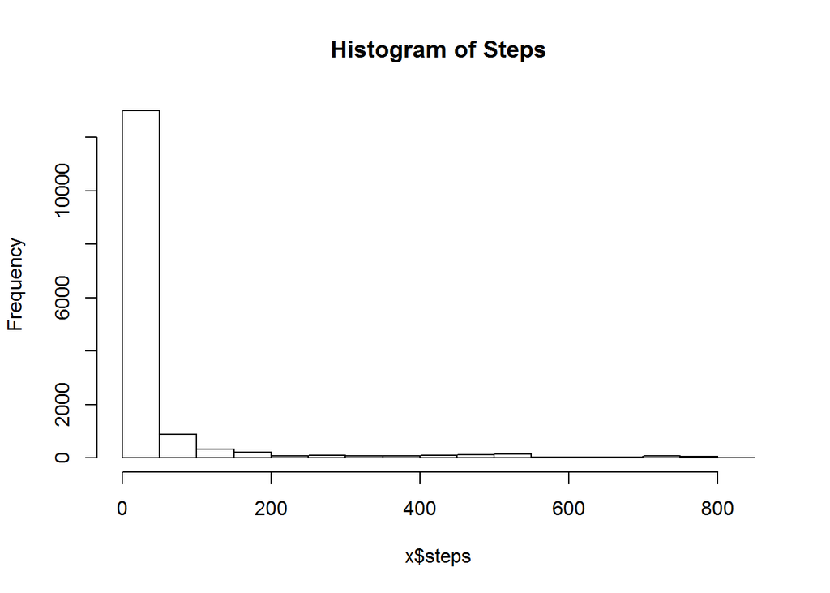

```
## [1] "Mean: 37.3825995807128"
## [1] "Median: 0"
```

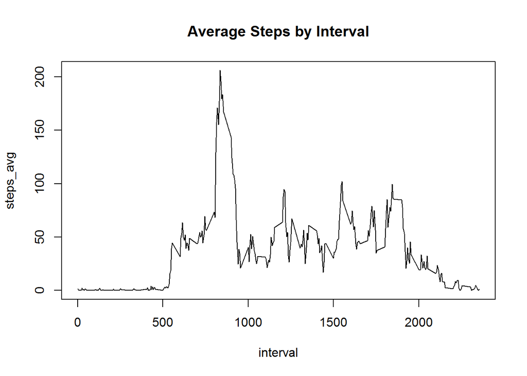

```
## [1] "Max Interval:"
##     interval steps_avg
## 104      835  206.1698
```

```r
# Run strategies
run_comparison(activity1)
```

Stategy 2:

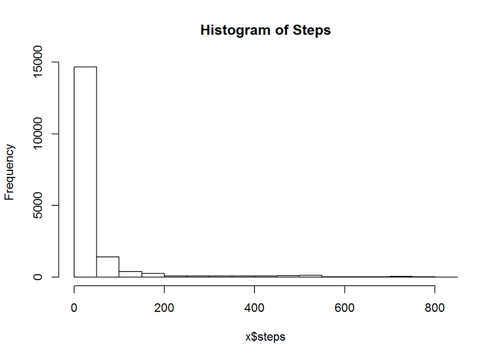

```
## [1] "Mean: 37.3825995807128"
## [1] "Median: 0"
```

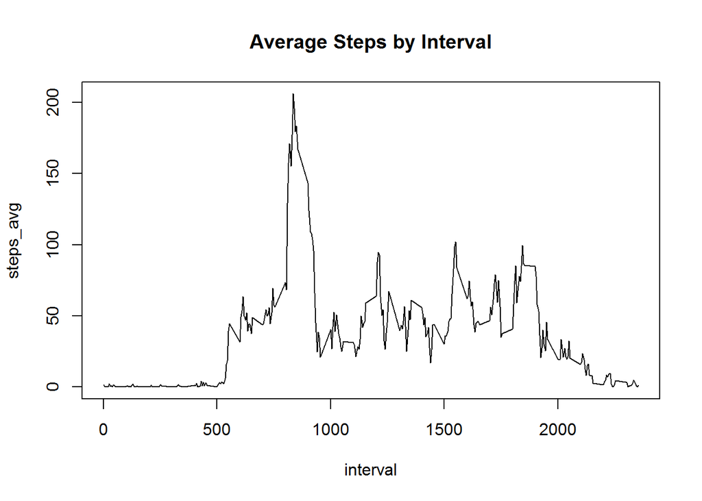

```
## [1] "Max Interval:"
##     interval steps_avg
## 104      835  206.1698
```

```r
# Run strategies
run_comparison(activity2)
```

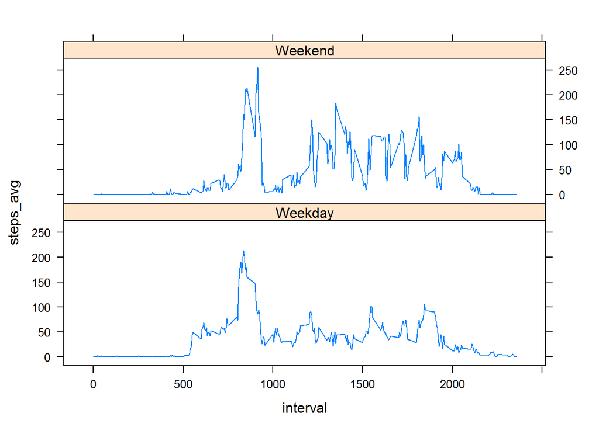

```r
# Run Weekday vs Weekend Analysis

# Aggregate by Interval
avg_interval_intervaldayoff <- aggregate(activity2$steps, by = list(activity2$interval, activity2$dayoff), mean)
colnames(avg_interval_intervaldayoff) <- c('interval', 'dayoff', 'steps_avg')

# Plot
with(avg_interval_intervaldayoff,
     xyplot(steps_avg~interval|dayoff,
            type = 'l',
            layout = c(1,2)))
```